# Speed_Dating_Analysis

```python
# importing the data

import pandas as pd

df = pd.read_csv('/content/Speed_Dating.csv', encoding = 'iso-8859-1')

df.head()
```

|  | iid | id | gender | idg | condtn | wave | round | position | positin1 | order | partner | pid | match | int_corr | samerace | age_o | race_o | pf_o_att | pf_o_sin | pf_o_int | pf_o_fun | pf_o_amb | pf_o_sha | dec_o | attr_o | sinc_o | intel_o | fun_o | amb_o | … |
| --- | --- | --- | --- | --- | --- | --- | --- | --- | --- | --- | --- | --- | --- | --- | --- | --- | --- | --- | --- | --- | --- | --- | --- | --- | --- | --- | --- | --- | --- | --- |
| 0 | 1 | 1.0 | 0 | 1 | 1 | 1 | 10 | 7 | NaN | 4 | 1 | 11.0 | 0 | 0.14 | 0 | 27.0 | 2.0 | 35.0 | 20.0 | 20.0 | 20.0 | 0.0 | 5.0 | 0 | 6.0 | 8.0 | 8.0 | 8.0 | 8.0 | … |
| 1 | 1 | 1.0 | 0 | 1 | 1 | 1 | 10 | 7 | NaN | 3 | 2 | 12.0 | 0 | 0.54 | 0 | 22.0 | 2.0 | 60.0 | 0.0 | 0.0 | 40.0 | 0.0 | 0.0 | 0 | 7.0 | 8.0 | 10.0 | 7.0 | 7.0 | … |
| 2 | 1 | 1.0 | 0 | 1 | 1 | 1 | 10 | 7 | NaN | 10 | 3 | 13.0 | 1 | 0.16 | 1 | 22.0 | 4.0 | 19.0 | 18.0 | 19.0 | 18.0 | 14.0 | 12.0 | 1 | 10.0 | 10.0 | 10.0 | 10.0 | 10.0 | … |
| 3 | 1 | 1.0 | 0 | 1 | 1 | 1 | 10 | 7 | NaN | 5 | 4 | 14.0 | 1 | 0.61 | 0 | 23.0 | 2.0 | 30.0 | 5.0 | 15.0 | 40.0 | 5.0 | 5.0 | 1 | 7.0 | 8.0 | 9.0 | 8.0 | 9.0 | … |
| 4 | 1 | 1.0 | 0 | 1 | 1 | 1 | 10 | 7 | NaN | 7 | 5 | 15.0 | 1 | 0.21 | 0 | 24.0 | 3.0 | 30.0 | 10.0 | 20.0 | 10.0 | 10.0 | 20.0 | 1 | 8.0 | 7.0 | 9.0 | 6.0 | 9.0 | … |

5 rows × 195 columns

```python
df.shape # checking how many rows and columns I'm working with
```

```
(8378, 195)
```

```python
df.isna().sum() # checking for NaN values
```

```
iid            0
id             1
gender         0
idg            0
condtn         0
            ...
attr5_3     6362
sinc5_3     6362
intel5_3    6362
fun5_3      6362
amb5_3      6362
Length: 195, dtype: int64
```

```python
# creating a new dataframe with only the columns I care about for the analysis

dating = (df.filter(['gender', 'order', 'match', 'age', 'field', 'field_cd', 'race', 'imprelig', 'from', 'goal', 'attr1_1', 'sinc1_1', 'intel1_1', 'fun1_1', 'amb1_1', 'shar1_1', 'attr_o', 'sinc_o', 'intel_o', 'fun_o', 'amb_o', 'shar_o', 'imprace'], axis = 1))

dating.head()
```

|  | gender | order | match | age | field | field_cd | race | imprelig | from | goal | attr1_1 | sinc1_1 | intel1_1 | fun1_1 | amb1_1 | shar1_1 | attr_o | sinc_o | intel_o | fun_o | amb_o | shar_o | imprace |
| --- | --- | --- | --- | --- | --- | --- | --- | --- | --- | --- | --- | --- | --- | --- | --- | --- | --- | --- | --- | --- | --- | --- | --- |
| 0 | 0 | 4 | 0 | 21.0 | Law | 1.0 | 4.0 | 4.0 | Chicago | 2.0 | 15.0 | 20.0 | 20.0 | 15.0 | 15.0 | 15.0 | 6.0 | 8.0 | 8.0 | 8.0 | 8.0 | 6.0 | 2.0 |
| 1 | 0 | 3 | 0 | 21.0 | Law | 1.0 | 4.0 | 4.0 | Chicago | 2.0 | 15.0 | 20.0 | 20.0 | 15.0 | 15.0 | 15.0 | 7.0 | 8.0 | 10.0 | 7.0 | 7.0 | 5.0 | 2.0 |
| 2 | 0 | 10 | 1 | 21.0 | Law | 1.0 | 4.0 | 4.0 | Chicago | 2.0 | 15.0 | 20.0 | 20.0 | 15.0 | 15.0 | 15.0 | 10.0 | 10.0 | 10.0 | 10.0 | 10.0 | 10.0 | 2.0 |
| 3 | 0 | 5 | 1 | 21.0 | Law | 1.0 | 4.0 | 4.0 | Chicago | 2.0 | 15.0 | 20.0 | 20.0 | 15.0 | 15.0 | 15.0 | 7.0 | 8.0 | 9.0 | 8.0 | 9.0 | 8.0 | 2.0 |
| 4 | 0 | 7 | 1 | 21.0 | Law | 1.0 | 4.0 | 4.0 | Chicago | 2.0 | 15.0 | 20.0 | 20.0 | 15.0 | 15.0 | 15.0 | 8.0 | 7.0 | 9.0 | 6.0 | 9.0 | 7.0 | 2.0 |

```python
dating.describe()
```

|  | gender | order | match | age | field_cd | race | imprelig | goal | attr1_1 | sinc1_1 | intel1_1 | fun1_1 | amb1_1 | shar1_1 | attr_o | sinc_o | intel_o | fun_o | amb_o | shar_o | imprace |
| --- | --- | --- | --- | --- | --- | --- | --- | --- | --- | --- | --- | --- | --- | --- | --- | --- | --- | --- | --- | --- | --- |
| count | 8378.000000 | 8378.000000 | 8378.000000 | 8283.000000 | 8296.000000 | 8315.000000 | 8299.000000 | 8299.000000 | 8299.000000 | 8299.000000 | 8299.000000 | 8289.000000 | 8279.000000 | 8257.000000 | 8166.000000 | 8091.000000 | 8072.000000 | 8018.000000 | 7656.000000 | 7302.000000 | 8299.000000 |
| mean | 0.500597 | 8.927668 | 0.164717 | 26.358928 | 7.662488 | 2.757186 | 3.651645 | 2.122063 | 22.514632 | 17.396389 | 20.265613 | 17.457043 | 10.682539 | 11.845111 | 6.190411 | 7.175256 | 7.369301 | 6.400599 | 6.778409 | 5.474870 | 3.784793 |
| std | 0.500029 | 5.477009 | 0.370947 | 3.566763 | 3.758935 | 1.230905 | 2.805237 | 1.407181 | 12.587674 | 7.046700 | 6.783003 | 6.085239 | 6.124888 | 6.362154 | 1.950305 | 1.740575 | 1.550501 | 1.954078 | 1.794080 | 2.156163 | 2.845708 |
| min | 0.000000 | 1.000000 | 0.000000 | 18.000000 | 1.000000 | 1.000000 | 1.000000 | 1.000000 | 0.000000 | 0.000000 | 0.000000 | 0.000000 | 0.000000 | 0.000000 | 0.000000 | 0.000000 | 0.000000 | 0.000000 | 0.000000 | 0.000000 | 0.000000 |
| 25% | 0.000000 | 4.000000 | 0.000000 | 24.000000 | 5.000000 | 2.000000 | 1.000000 | 1.000000 | 15.000000 | 15.000000 | 17.390000 | 15.000000 | 5.000000 | 9.520000 | 5.000000 | 6.000000 | 6.000000 | 5.000000 | 6.000000 | 4.000000 | 1.000000 |
| 50% | 1.000000 | 8.000000 | 0.000000 | 26.000000 | 8.000000 | 2.000000 | 3.000000 | 2.000000 | 20.000000 | 18.180000 | 20.000000 | 18.000000 | 10.000000 | 10.640000 | 6.000000 | 7.000000 | 7.000000 | 7.000000 | 7.000000 | 6.000000 | 3.000000 |
| 75% | 1.000000 | 13.000000 | 0.000000 | 28.000000 | 10.000000 | 4.000000 | 6.000000 | 2.000000 | 25.000000 | 20.000000 | 23.810000 | 20.000000 | 15.000000 | 16.000000 | 8.000000 | 8.000000 | 8.000000 | 8.000000 | 8.000000 | 7.000000 | 6.000000 |
| max | 1.000000 | 22.000000 | 1.000000 | 55.000000 | 18.000000 | 6.000000 | 10.000000 | 6.000000 | 100.000000 | 60.000000 | 50.000000 | 50.000000 | 53.000000 | 30.000000 | 10.500000 | 10.000000 | 10.000000 | 11.000000 | 10.000000 | 10.000000 | 10.000000 |

- columns with a "_o" such as "amb_o", "sinc_o" are what each participant rated their date on a scale of 1 - 10 on sincerity, ambition, etc
- columns with "1_1" such as "amb1_1", "sinc1_1" are how important that attribute (ambition, sincerity, etc) is to the participant (some were asked to rate from 0 - 10 and some were asked to distribute 100 points amongst all of the attributes)

```python
# making everything lowercase in the 'field' and 'from' columns

dating['field'] = dating['field'].str.lower()
dating['from'] = dating['from'].str.lower()
```

## **What was everyone's goal in participating in the speed dating event?**

```python
# replacing all of the numerical values with their categorical value

dating['goal'].replace(1, 'Seemed like a fun night out', inplace=True)
dating['goal'].replace(2, 'To meet new people', inplace=True)
dating['goal'].replace(3, 'To get a date', inplace=True)
dating['goal'].replace(4, 'Looking for a serious relationship', inplace=True)
dating['goal'].replace(5, 'To say I did it', inplace=True)
dating['goal'].replace(6, 'Other', inplace=True)
```

```python
import plotly.express as px
import plotly.io as pio

pio.renderers.default = "svg"

fig = px.histogram(dating, x = "goal", color_discrete_sequence = ['#ff69b4'], title = 'Primary Goal of Participating', width=700, height=600)

fig.show()
```

[interactive chart not shown]

Very few participants were actually looking for a serious relationship. Most participants just wanted to have fun and meet new people.

# What are the participants studying in school?

```python
# replacing all of the numerical values with their categorical value, to make the histograms clearer/easier to read

dating2 = dating['field_cd'].replace(1, 'Law', inplace=True)
dating2 = dating['field_cd'].replace(2, 'Math', inplace=True)
dating2 = dating['field_cd'].replace(3, 'Social Science/Psychology', inplace=True)
dating2 = dating['field_cd'].replace(4, 'Medical Science/Pharma/Bio-Tech', inplace=True)
dating2 = dating['field_cd'].replace(5, 'Engineering', inplace=True)
dating2 = dating['field_cd'].replace(6, 'English/Writing/Journalism', inplace=True)
dating2 = dating['field_cd'].replace(7, 'History/Religion/Philosophy', inplace=True)
dating2 = dating['field_cd'].replace(8, 'Business/Econ/Finance', inplace=True)
dating2 = dating['field_cd'].replace(9, 'Education', inplace=True)
dating2 = dating['field_cd'].replace(10, 'Biological Sciences/Chemistry/Physics', inplace=True)
dating2 = dating['field_cd'].replace(11, 'Social Work', inplace=True)
dating2 = dating['field_cd'].replace(12, 'Undecided', inplace=True)
dating2 = dating['field_cd'].replace(13, 'Political Science/International Affairs ', inplace=True)
dating2 = dating['field_cd'].replace(14, 'Film', inplace=True)
dating2 = dating['field_cd'].replace(15, 'Fine Arts/Arts Administration', inplace=True)
dating2 = dating['field_cd'].replace(16, 'Languages', inplace=True)
dating2 = dating['field_cd'].replace(17, 'Architecture', inplace=True)
dating2 = dating['field_cd'].replace(18, 'Other', inplace=True)
```

```python
dating['field_cd'].value_counts()  # counting frequency across column values
```

```
Business/Econ/Finance                       1925
Biological Sciences/Chemistry/Physics        993
Engineering                                  864
Political Science/International Affairs      709
Social Science/Psychology                    696
Law                                          665
Education                                    626
Social Work                                  468
English/Writing/Journalism                   325
History/Religion/Philosophy                  241
Math                                         207
Fine Arts/Arts Administration                187
Medical Science/Pharma/Bio-Tech              143
Film                                         126
Other                                         52
Languages                                     40
Undecided                                     19
Architecture                                  10
Name: field_cd, dtype: int64
```

```python
dating['field_of_study'] = dating['field_cd'] # changing the column name
```

```python
# Field of Study Histogram

fig = px.histogram(dating, x = "field_of_study", color_discrete_sequence = ['#dc143c'], title = 'Field of Study')

fig.show()
```

[interactive chart not shown]

The top three fields of study were Business/Finance, Science (Chemistry/Physics), and Engineering!

# How old were the participants?

```python
dating['age'].value_counts().head() # counting the frequency of age values
```

```
27.0    1059
23.0     894
26.0     869
24.0     863
25.0     837
Name: age, dtype: int64
```

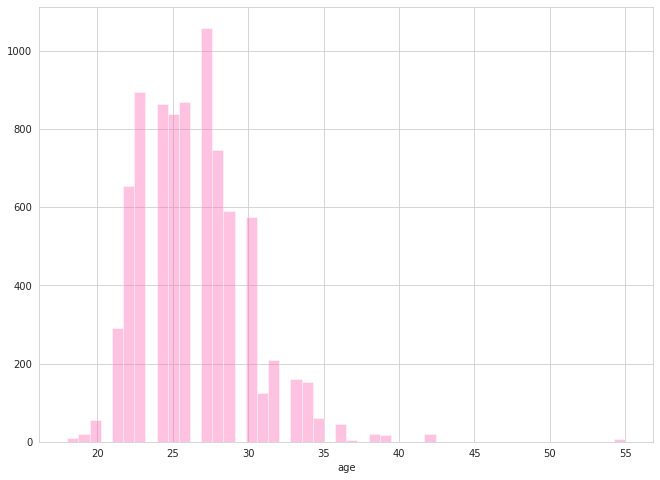

```python
import seaborn as sns
%matplotlib inline
sns.set_style('whitegrid')
from pandas.testing import assert_frame_equal
import matplotlib.pyplot as plt

plt.figure(figsize=(11, 8))

# plotting the frequency distribution

sns.distplot(dating['age'], kde = False, color = 'hotpink')
```

Most participants were in their mid to late 20's!

# Where were the participants from?

```python
dating['from'].value_counts().head(20) # counting the fequency of each location
```

```
new york          579
new jersey        381
california        345
new york city     161
china             144
italy             132
boston            123
texas             120
nyc               119
india             113
taiwan            113
maryland          106
spain             105
israel            104
france            104
los angeles       100
chicago            95
washington, dc     87
boston, ma         87
san francisco      84
Name: from, dtype: int64
```

```python
# replacing values to fall under the right state/country category

dating['from'] = dating['from'].replace(['bronx science', 'long island, ny', 'manhattan', 'westchester, ny','ny','westchester county, n.y.', 'nyc (staten island)', 'queens', 'hastings-on-hudson, ny', 'staten island', 'great neck, ny', 'westchester, new york', 'upstate new york','nyc', 'new york city', 'rochester, ny','buffalo, ny','pougkeepsie ny', 'brooklyn', 'brooklyn, ny', 'brooklyn ny', 'long island', 'new york, ny'], 'new york')
dating['from'] = dating['from'].replace(['nj', 'cherry hill, nj', 'northern new jersey', 'south orange, new jersey', 'born in montana, raised in south jersey (nr. philadelphia', 'born in montana, raised in south jersey (nr. philadelphia)'], 'new jersey')
dating['from'] = dating['from'].replace(['san francisco, ca', 'san francisco(home)/los angeles(undergrad)', 'sf bay area, ca', 'san francisco bay area', 'palo alto, california', 'palo alto, ca','berkeley, ca', 'los angeles', 'california (west coast)', 'palm springs, california', 'santa barbara, california', 'los angeles, ca', 'san francisco', 'san diego', 'san diego, ca', 'southern california', 'northern california', 'torrance, ca'], 'california')
dating['from'] = dating['from'].replace(['state college, pa', 'pittsburgh, pa', 'erie, pa', 'pa', 'philadelphia, pa'], 'pennsylvania')
dating['from'] = dating['from'].replace(['new delhi', 'new delhi, india', 'bombay, india'], 'india')
dating['from'] = dating['from'].replace(['brandeis university', 'woburn, ma', 'boston, ma', 'cambridge, ma', 'cambridge, massachusetts', 'lexington, ma'], 'massachussetts')
dating['from'] = dating['from'].replace(['ann arbor, mi'], 'michigan')
dating['from'] = dating['from'].replace(['atlanta, ga', 'georgia, usa'], 'georgia')
dating['from'] = dating['from'].replace(['clevel,', 'cincinnati, oh', 'cincinnati, ohio'], 'ohio')
dating['from'] = dating['from'].replace(['wash dc (4 yrs)', 'dc','washington dc metro region', 'washington state', 'washington, d.c.', 'washington, dc', 'washington dc'], 'washington')
dating['from'] = dating['from'].replace(['portland, oregon', 'portland, or'], 'oregon')
dating['from'] = dating['from'].replace(['detroit, michigan, usa', 'detroit suburbs', 'ann arbor'], 'michigan')
dating['from'] = dating['from'].replace(['dallas, texas', 'austin, tx'], 'texas')
dating['from'] = dating['from'].replace(['albuquerque, nm'], 'new mexico')
dating['from'] = dating['from'].replace(['st. louis, mo', 'kansas city, missouri'], 'missouri')
dating['from'] = dating['from'].replace(['milwaukee, wisconsin'], 'wisconsin')
dating['from'] = dating['from'].replace(['nashville, tn', 'memphis, tn', 'tn'], 'tennessee')
dating['from'] = dating['from'].replace(['tuscaloosa, alabama'], 'alabama')
dating['from'] = dating['from'].replace(['greenwich, ct'], 'connecticut')
dating['from'] = dating['from'].replace(['maryl,', 'silver spring, md', 'md'], 'maryland')
dating['from'] = dating['from'].replace(['burlington, vermont'], 'vermont')
dating['from'] = dating['from'].replace(['minneapolis, mn'], 'minnessota')
dating['from'] = dating['from'].replace(['milano, italy', 'milan - italy'], 'italy')
dating['from'] = dating['from'].replace(['p. r. china', 'shanghai, china'], 'china')
dating['from'] = dating['from'].replace(['bowdoin college'], 'maine')
dating['from'] = dating['from'].replace(['nyc-6 yrs. grew up in nebraska'], 'nebraska')
dating['from'] = dating['from'].replace(['manila, philippines'], 'phillippines')
dating['from'] = dating['from'].replace(['bogota, colombia', 'colombia, south america'], 'colombia')
dating['from'] = dating['from'].replace(['engl,', 'london, uk'], 'united kingdom')
dating['from'] = dating['from'].replace(['ottawa, canada', 'toronto, canada'], 'canada')
dating['from'] = dating['from'].replace(['sofia, bg'], 'bulgaria')
dating['from'] = dating['from'].replace(['tokyo, japan'], 'japan')
dating['from'] = dating['from'].replace(['/', ' / ', '  / ', '  , ', ',  '], ', ', regex = True)
dating['from'] = dating['from'].replace(['asia, singapore'], 'singapore')
dating['from'] = dating['from'].replace(['taipei, taiwan'], 'taiwan')
dating['from'] = dating['from'].replace(['uncc'], 'north carolina')
dating['from'] = dating['from'].replace(['and', '&'], ', ', regex = True)


# replacing the value in this row because it's a zip code

dating['from'] = dating['from'].str.replace('94115', 'california')
```

```python
# creating a dataframe of the column 'from' so that I can plot the top 10 locations

data = pd.DataFrame(dating['from'].value_counts().head(10))

data
```

|  | from |
| --- | --- |
| new york | 1325 |
| california | 856 |
| new jersey | 529 |
| washington | 243 |
| china | 181 |
| massachussetts | 172 |
| india | 155 |
| italy | 152 |
| texas | 148 |
| pennsylvania | 147 |

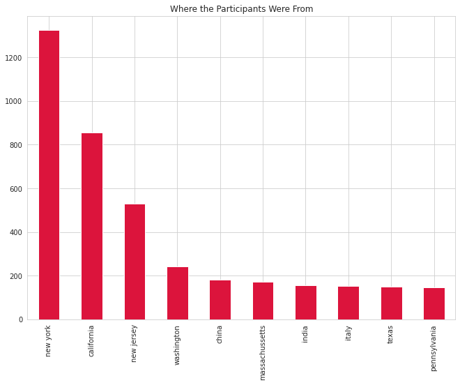

```python
# plotting the location counts

plt.figure(figsize=(11, 8))

pd.value_counts(dating['from']).head(10).plot.bar(color = '#dc143c', title = 'Where the Participants Were From')
```

A lot of the participants were from New York, California, and Jersey. There were also people from all over the world that participated, such as China, India, and Italy.

# What do people look for in a partner? What attributes are most important to men and women?

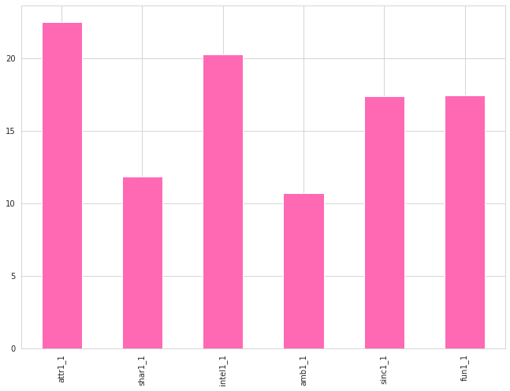

```python
# creating a new dataframe with only the columns where the attributes were rated on how important they are to the participants

importance = (dating.filter(['attr1_1','shar1_1','intel1_1','amb1_1','sinc1_1','fun1_1']))

# plotting the means of all of the columns in the dataframe

plt.figure(figsize=(11, 8))

importance.mean().plot.bar(color = '#ff69b4')
```

**Attractiveness**, **intelligence**, and how **fun** their partner is, are most important to the participants.

```python
# box chart showing how much women and men care about AMBITION in a potential partner when it comes to dating

px.box(data_frame = dating, x = 'gender', y = 'amb1_1', title = 'Importance of Ambition', width=700, height=600, color_discrete_sequence = ['#ff69b4'] )
```

[interactive chart not shown]

I notice an outlier on the male side!

```python
dating[dating['amb1_1']>50] # finding the rows with outliers
```

|  | gender | order | match | age | field | field_cd | race | imprelig | from | goal | attr1_1 | sinc1_1 | intel1_1 | fun1_1 | amb1_1 | shar1_1 | attr_o | sinc_o | intel_o | fun_o | amb_o | shar_o | imprace | field_of_study |
| --- | --- | --- | --- | --- | --- | --- | --- | --- | --- | --- | --- | --- | --- | --- | --- | --- | --- | --- | --- | --- | --- | --- | --- | --- |
| 908 | 1 | 7 | 0 | 29.0 | business & international affairs | Business/Econ/Finance | 3.0 | 1.0 | mexico | To meet new people | 20.0 | 25.0 | 15.0 | 15.0 | 53.0 | 20.0 | 2.0 | 6.0 | 2.0 | 3.0 | 2.0 | 3.0 | 1.0 | Business/Econ/Finance |
| 909 | 1 | 6 | 0 | 29.0 | business & international affairs | Business/Econ/Finance | 3.0 | 1.0 | mexico | To meet new people | 20.0 | 25.0 | 15.0 | 15.0 | 53.0 | 20.0 | 8.0 | 7.0 | 7.0 | 7.0 | 7.0 | 7.0 | 1.0 | Business/Econ/Finance |
| 910 | 1 | 9 | 0 | 29.0 | business & international affairs | Business/Econ/Finance | 3.0 | 1.0 | mexico | To meet new people | 20.0 | 25.0 | 15.0 | 15.0 | 53.0 | 20.0 | 4.0 | 9.0 | 9.0 | 8.0 | 8.0 | 5.0 | 1.0 | Business/Econ/Finance |
| 911 | 1 | 10 | 0 | 29.0 | business & international affairs | Business/Econ/Finance | 3.0 | 1.0 | mexico | To meet new people | 20.0 | 25.0 | 15.0 | 15.0 | 53.0 | 20.0 | NaN | NaN | NaN | NaN | NaN | NaN | 1.0 | Business/Econ/Finance |
| 912 | 1 | 8 | 1 | 29.0 | business & international affairs | Business/Econ/Finance | 3.0 | 1.0 | mexico | To meet new people | 20.0 | 25.0 | 15.0 | 15.0 | 53.0 | 20.0 | 9.0 | 10.0 | 10.0 | 5.0 | NaN | NaN | 1.0 | Business/Econ/Finance |
| 913 | 1 | 1 | 0 | 29.0 | business & international affairs | Business/Econ/Finance | 3.0 | 1.0 | mexico | To meet new people | 20.0 | 25.0 | 15.0 | 15.0 | 53.0 | 20.0 | 5.0 | 8.0 | 7.0 | 8.0 | 8.0 | 3.0 | 1.0 | Business/Econ/Finance |
| 914 | 1 | 5 | 0 | 29.0 | business & international affairs | Business/Econ/Finance | 3.0 | 1.0 | mexico | To meet new people | 20.0 | 25.0 | 15.0 | 15.0 | 53.0 | 20.0 | 6.0 | 7.0 | 7.0 | 7.0 | 8.0 | 6.0 | 1.0 | Business/Econ/Finance |
| 915 | 1 | 4 | 0 | 29.0 | business & international affairs | Business/Econ/Finance | 3.0 | 1.0 | mexico | To meet new people | 20.0 | 25.0 | 15.0 | 15.0 | 53.0 | 20.0 | 2.0 | 7.0 | 7.0 | 5.0 | 4.0 | 2.0 | 1.0 | Business/Econ/Finance |
| 916 | 1 | 2 | 0 | 29.0 | business & international affairs | Business/Econ/Finance | 3.0 | 1.0 | mexico | To meet new people | 20.0 | 25.0 | 15.0 | 15.0 | 53.0 | 20.0 | 7.0 | 7.0 | 8.0 | 6.0 | 8.0 | 5.0 | 1.0 | Business/Econ/Finance |
| 917 | 1 | 3 | 0 | 29.0 | business & international affairs | Business/Econ/Finance | 3.0 | 1.0 | mexico | To meet new people | 20.0 | 25.0 | 15.0 | 15.0 | 53.0 | 20.0 | 6.0 | 7.0 | 8.0 | 7.0 | 8.0 | 6.0 | 1.0 | Business/Econ/Finance |

```python
dating = dating[dating.amb1_1 != 53] # removing every row in the amb1_1 column with the value 53 so that there are no longer outliers
```

```python
# reprinting the box plot now that the outlier is removed

px.box(data_frame = dating, x = 'gender', y = 'amb1_1', title = 'Importance of Ambition', width=700, height=600, color_discrete_sequence = ['#ff69b4'])
```

[interactive chart not shown]

Women seem to care a bit more about ambition than men!

```python
# box chart showing how much women and men care about ATTRACTIVENESS in a potential partner when it comes to dating

px.box(data_frame = dating, x = 'gender', y = 'attr1_1', title = 'Importance of Attractiveness', width=700, height=600, color_discrete_sequence = ['#ff69b4'])
```

[interactive chart not shown]

On average, it seems like men care more about looks than women do!

```python
# box chart showing how much women and men care about having SHARED INTERESTS when it comes to dating

px.box(data_frame = dating, x = 'gender', y = 'shar1_1', title = 'Importance of Having Shared Interests', width=700, height=600, color_discrete_sequence = ['#ff69b4'])
```

[interactive chart not shown]

On average, it seems like women care more about having shared interests than men!

## **How important is being the same race?**

```python
# replacing the numerical values with their categorical value

dating['race'].replace(1, 'Black/African American', inplace = True)
dating['race'].replace(2, 'European/Caucasian-American', inplace = True)
dating['race'].replace(3, 'Latino/Hispanic American', inplace = True)
dating['race'].replace(4, 'Asian/Pacific Islander/Asian-American', inplace = True)
dating['race'].replace(5, 'Native American', inplace = True)
dating['race'].replace(6, 'Other', inplace = True)
```

```python
# histogram displaying the races of the participants

fig = px.histogram(dating, x = "race", color_discrete_sequence = ['#dc143c'], title = 'Participant Races', width=700, height=600)

fig.show()
```

[interactive chart not shown]

Most participants were either **European/Caucasian-American** or **Asian/Pacific-Islander/Asian-American**.

```python
fig = px.histogram(dating, x = "imprace", color_discrete_sequence = ['#ff69b4'], title = 'How Important is Race from 0 - 10?', width=700, height=600)

fig.show()
```

[interactive chart not shown]

For a lot of participants, it doesn't seem like race is a huge factor!

# Exploring Matches! How did people rate their dates? What does this say about what they *really* value/find important in a partner?

```python
dating['match'].value_counts()
```

```
0    6989
1    1379
Name: match, dtype: int64
```

There were **1,379** matches out of **8,368** dates!

```python
# filtering out a new dataframe so I can plot the distribution of the rating of their dates by match (1) and no match (0)

matchesdf = (dating.filter(['amb_o','intel_o','sinc_o','fun_o','attr_o','shar_o', 'match']))
```

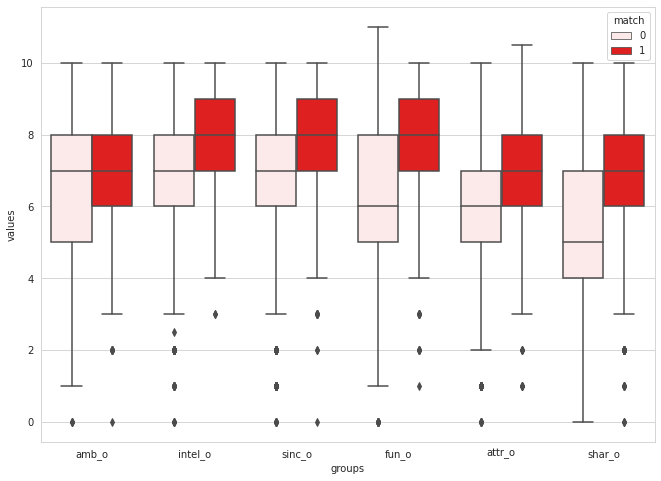

```python
import plotly.graph_objects as go

df = pd.DataFrame(data)

# convert to long

dfl = matchesdf.set_index('match').stack().reset_index().rename(columns={'level_1': 'groups', 0: 'values'})

plt.figure(figsize=(11, 8))

# plot

p = sns.boxplot(x='groups', y='values', data=dfl, hue='match', color = 'red')
plt.show()
```

It looks like shared interests and fun are going to be significant. There is a big difference in the mean of fun for the dates that ended up in a match vs the mean of fun for the dates that ended up without a match. Same for shared interests. For ambition the mean was the same, so it doesn't seem like ambition matters much.

```python
# creating a new dataframe filtering out columns that I want to place in a heatmap

newdf = (dating.filter(['round', 'match', 'age', 'race', 'attr_o', 'sinc_o', 'intel_o', 'fun_o', 'amb_o', 'shar_o',
                      ], axis = 1))

newdf.head()
```

|  | match | age | race | attr_o | sinc_o | intel_o | fun_o | amb_o | shar_o |
| --- | --- | --- | --- | --- | --- | --- | --- | --- | --- |
| 0 | 0 | 21.0 | Asian/Pacific Islander/Asian-American | 6.0 | 8.0 | 8.0 | 8.0 | 8.0 | 6.0 |
| 1 | 0 | 21.0 | Asian/Pacific Islander/Asian-American | 7.0 | 8.0 | 10.0 | 7.0 | 7.0 | 5.0 |
| 2 | 1 | 21.0 | Asian/Pacific Islander/Asian-American | 10.0 | 10.0 | 10.0 | 10.0 | 10.0 | 10.0 |
| 3 | 1 | 21.0 | Asian/Pacific Islander/Asian-American | 7.0 | 8.0 | 9.0 | 8.0 | 9.0 | 8.0 |
| 4 | 1 | 21.0 | Asian/Pacific Islander/Asian-American | 8.0 | 7.0 | 9.0 | 6.0 | 9.0 | 7.0 |

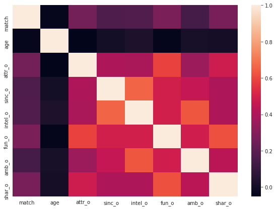

```python
import matplotlib.pyplot as plt

plt.figure(figsize=(10, 7))

# Calculate correlations of the new dataframe
corr = newdf.corr()

# Heatmap
sns.heatmap(corr, )
```

It looks like how *attractive and fun their date is, and how much they have in common with them (shared interests)* are most highly correlated with getting a match.

Other things to note:

- intelligence and ambition are correlated
- attractiveness and fun are correlated
- shared interests and fun are correlated

## Logistic Regression

```python
dating = dating.dropna()  # dropping all rows with NaN values so that the regression can run
```

```python
# replacing race with their numerical values so that the regression will run

dating['race'].replace('Black/African American', 1,  inplace = True)
dating['race'].replace('European/Caucasian-American', 2, inplace = True)
dating['race'].replace('Latino/Hispanic American', 3,  inplace = True)
dating['race'].replace('Asian/Pacific Islander/Asian-American', 4, inplace = True)
dating['race'].replace('Native American', 5, inplace = True)
dating['race'].replace('Other', 6, inplace = True)
```

```python
from sklearn.linear_model import LogisticRegression
from scipy import stats

# my independent variables are age, race, and what each participant rated their date among the 6 attributes

X2 = dating[['attr_o','sinc_o','intel_o','fun_o','amb_o','shar_o','age','race',]]
y = dating['match']

# fitting the model

dating_log_model = LogisticRegression(solver='liblinear')
dating_log_model.fit(X2,y)
dating_log_model.score(X2,y)
```

```
0.823111497752646
```

The model has 82% accuracy!

```python
from sklearn.feature_selection import chi2

# getting the p-values of all of the independent variables

scores, pvalues = chi2(X2, y)
```

```python
p_values = {'X2':X2.columns, 'pvalues':pvalues}

# creating a new dataframe of all of the p-values to visualize them

result = pd.DataFrame(p_values)

print(result)
```

```
        X2       pvalues
0   attr_o  5.671414e-67
1   sinc_o  1.192611e-19
2  intel_o  1.070280e-16
3    fun_o  4.918223e-72
4    amb_o  7.736045e-17
5   shar_o  1.266971e-96
6      age  1.178410e-01
7     race  8.548411e-01
```

Like the analysis suggested, **shared interests**, **fun**, and **attractiveness** are the most significant variables! Ambition and intelligence are the **least** significant of the 6 rated attributes.

## Good news! If you're not someones physical type, it doesn't seem to matter as much as how much you have in common in terms of interests and how fun you are to be around!

Conclusion:

The participants found attractiveness, intelligence, and fun to be the most important attributes to them when asked (in that order), however, their decisions when it came to matching said something else. Attractiveness isn't as important as the participants considered it to be. The regression reveals that having *shared interests* holds more weight than both attractiveness and fun, and intelligence isn't as important as they thought it was to them!

So if you find yourself on Hinge, Bumble, or Tinder:

- include pictures of your adventures, to show what kind of person you are to be around/ how fun you are
- include pictures of you engaging in your hobbies (whether it's running, painting, etc.) so that people can see what you're interested in
- make sure to read bio's and prompts to get a glimpse into each person's interests and see if they align with yours... because, who knows...it could lead to a match!